# A3: Incarceration

### Introduction

Introduction Incarceration rates in the United States have been a topic of significant concern and study for decades. Understanding the dynamics of incarceration rates, particularly how they vary by race, gender, and geographic location, is crucial for informing policies and interventions aimed at reducing mass incarceration and addressing racial disparities in the criminal justice system. This report analyzes various measures of incarceration using data on jail and prison population rates across different counties in Washington state from 1990 onwards. The primary variables of interest include total jail and prison population rates, disaggregated by race and gender.

The Dataset The dataset used in this analysis was collected by the Vera Institute of Justice, a non-profit organization focused on justice reform. The data was compiled from various sources, including government reports and correctional institution records, to provide a comprehensive view of incarceration rates over time. The primary purpose of collecting this data is to support research and advocacy efforts aimed at understanding and reducing mass incarceration.

Number of Observations: The dataset contains 308 observations (rows), representing different counties and years. Number of Features: There are 23 features (columns) in the dataset, including variables such as county name, year, total population, jail and prison population rates disaggregated by race and gender, and urbanicity. Ethical Considerations: When working with incarceration data, it is important to consider the ethical implications, such as the potential for reinforcing racial stereotypes or biases. Additionally, the privacy and dignity of individuals represented in the data must be safeguarded. It is crucial to use the data responsibly, ensuring that analyses and conclusions drawn do not perpetuate injustice or discrimination.

Limitations: One limitation of the dataset is the potential for missing or incomplete data, which can affect the accuracy of analyses. Additionally, the data may not capture all factors influencing incarceration rates, such as socio-economic conditions or changes in law enforcement practices. There may also be inconsistencies in how data was reported by different counties, which could impact the comparability of the results.

### Trends Over Time Chart

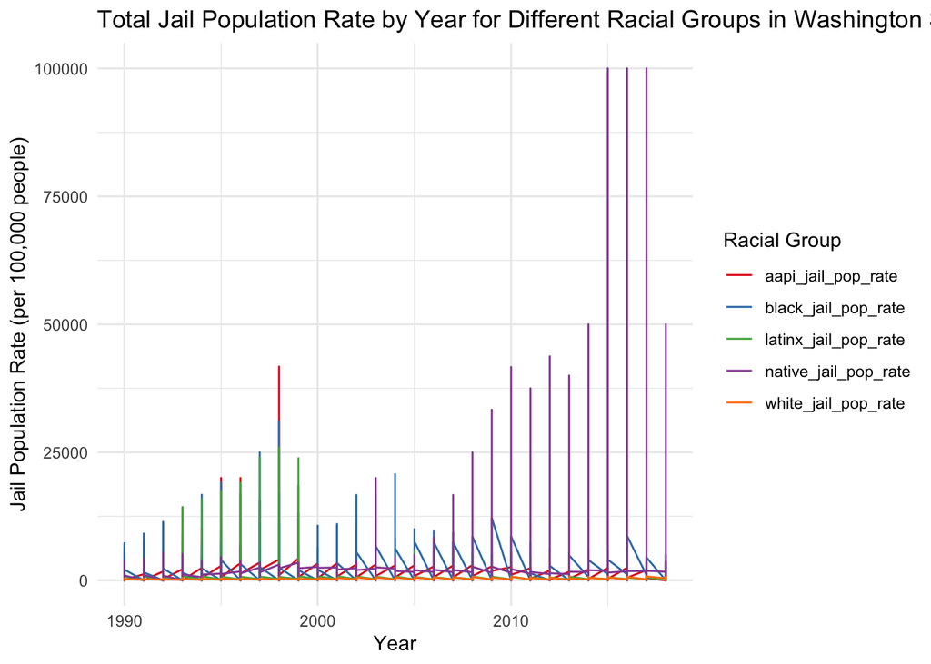

```r
if (!requireNamespace("ggplot2", quietly = TRUE)) {
  install.packages("ggplot2")
}
if (!requireNamespace("dplyr", quietly = TRUE)) {
  install.packages("dplyr")
}
if (!requireNamespace("tidyr", quietly = TRUE)) {
  install.packages("tidyr")
}


library(ggplot2)
library(dplyr)
library(tidyr)


data <- read.csv("us-prison-jail-rates-1990-WA.csv")


racial_groups <- c("aapi_jail_pop_rate", "black_jail_pop_rate", "latinx_jail_pop_rate", "native_jail_pop_rate", "white_jail_pop_rate")
data_long <- data %>%
  select(year, county_name, all_of(racial_groups)) %>%
  pivot_longer(cols = racial_groups, names_to = "Race", values_to = "Jail_Population_Rate")
ggplot(data_long, aes(x = year, y = Jail_Population_Rate, color = Race)) +
  geom_line() +
  labs(title = "Total Jail Population Rate by Year for Different Racial Groups in Washington State",
       x = "Year", y = "Jail Population Rate (per 100,000 people)") +
  theme_minimal() +
  scale_color_brewer(palette = "Set1", name = "Racial Group")
```

### Variable Comparison Chart

Variable Comparison Chart The second chart compares the total jail population rate with the total prison population rate across counties in Washington state. This comparison helps to explore the relationship between these two measures of incarceration.

[figure not shown]

```r
if (!requireNamespace("ggplot2", quietly = TRUE)) {
  install.packages("ggplot2")
}
if (!requireNamespace("dplyr", quietly = TRUE)) {
  install.packages("dplyr")
}


library(ggplot2)
library(dplyr)

data <- read.csv("us-prison-jail-rates-1990-WA.csv")


latest_year_data <- data %>%
  group_by(county_name) %>%
  filter(year == max(year)) %>%
  ungroup()

ggplot(latest_year_data, aes(x = total_jail_pop_rate, y = total_prison_pop_rate, color = urbanicity)) +
  geom_point() +
  labs(title = "Total Jail Population Rate vs Total Prison Population Rate by Urbanicity",
       x = "Total Jail Population Rate (per 100,000 people)", y = "Total Prison Population Rate (per 100,000 people)") +
  theme_minimal() +
  scale_color_brewer(palette = "Set1", name = "Urbanicity")
```

### Map

Map The map included in this report shows the geographic distribution of total jail population rates across different counties in Washington state. This visualization is essential for understanding how incarceration rates vary by location and can highlight regions with particularly high or low rates of incarceration.

Patterns Observed:

Spatial Variation: The map reveals significant spatial variation in jail population rates, with some counties exhibiting much higher rates than others. Urban vs. Rural: Counties with higher jail population rates tend to be more rural, indicating potential differences in law enforcement practices or socio-economic factors. Concentration of High Rates: Certain regions show a concentration of high incarceration rates, which could be indicative of localized issues that warrant further investigation.

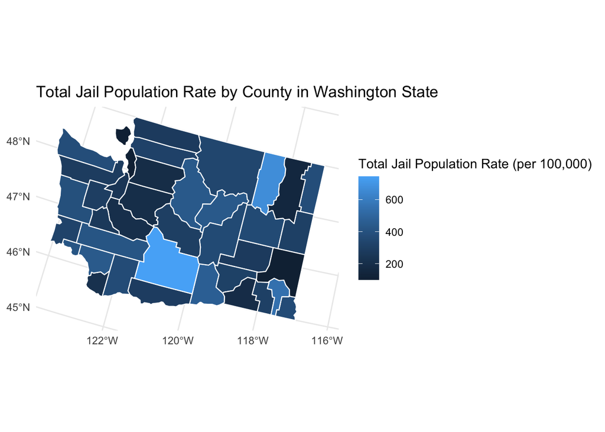

```r
if (!requireNamespace("usmap", quietly = TRUE)) {
  install.packages("usmap")
}
if (!requireNamespace("ggplot2", quietly = TRUE)) {
  install.packages("ggplot2")
}
if (!requireNamespace("dplyr", quietly = TRUE)) {
  install.packages("dplyr")
}


library(usmap)
library(ggplot2)
library(dplyr)


data <- read.csv("us-prison-jail-rates-1990-WA.csv")


latest_year_data <- data %>%
  group_by(county_name) %>%
  filter(year == max(year)) %>%
  ungroup()


plot_usmap(data = latest_year_data, regions = "counties", include = "WA", values = "total_jail_pop_rate", color = "white") +
  scale_fill_continuous(name = "Total Jail Population Rate (per 100,000)", label = scales::comma) +
  theme_minimal() +
  labs(title = "Total Jail Population Rate by County in Washington State") +
  theme(legend.position = "right")
```